# A1 Summary with 2019 Method

Samuel Ingloff-Richards

2025-09-25

# Preview data and matrices

## A1 Dataset

```
## [1] 769   7
```

```
##   ISO  L1_pop             region Glottocode Latitude Longitude Phoneme.Inventory.Size
## 1 aar 1379200             Africa   afar1241 12.22810  41.80830                     27
## 2 aau    7270 South-Eastern Asia   abau1245 -3.97222 141.32400                     14
## 3 abb   12000             Africa   bank1256  4.37020   9.64030                     33
## 4 abi   50500     Western Africa   abid1235  5.65656  -4.58421                     36
## 5 abt   44000            Oceania   ambu1247 -3.78010 143.05900                     24
## 6 abu   55100     Western Africa   abur1243  5.21534  -3.64123                     34
```

## Overview

- 769 languages in dataset

## Spatial Distance (3) Matrix

```
## [1] "769" "769"
```

```
## [1] "Is symmetric?  TRUE"
```

```
##           aar        aau       abb         abi        abt         abu
## aar     0.000 10943.3656  3364.040  4893.97084 11140.7516  4780.50611
## aau 10943.366     0.0000 14628.027 16196.21266   139.1289 16075.35124
## abb  3364.040 14628.0266     0.000  1547.22853 14834.2933  1421.87744
## abi  4893.971 16196.2127  1547.229     0.00000 16400.4031    53.62059
## abt 11140.752   139.1289 14834.293 16400.40311     0.0000 16280.22994
## abu  4780.506 16075.3512  1421.877    53.62059 16280.2299     0.00000
```

## Phylogenetic (3) Matrix

```
## [1] 769 769
```

```
## [1] "Is symmetric?  TRUE"
```

```
##     aar aau    abb    abi abt    abu
## aar   1   0 0.0000 0.0000   0 0.0000
## aau   0   1 0.0000 0.0000   0 0.0000
## abb   0   0 1.0000 0.0391   0 0.0391
## abi   0   0 0.0391 1.0000   0 0.1173
## abt   0   0 0.0000 0.0000   1 0.0000
## abu   0   0 0.0391 0.1173   0 1.0000
```

# Variable Table

| Variable | Definition | Example (abu, abur1243, Abure) | Source |
| --- | --- | --- | --- |
| Phoneme.Inventory.Size | Number of phonemes in a language inventory. | 34 | (4) |
| L1_pop | Number of L1 speakers for a language | 55100 | (3) |

# Method Overview

1. Merge data from (3) and (4).
2. Remove NA entries in merged data.
3. Remove duplicate languages (due to Phoible having multiple inventories for same language, or many Glottocodes for ISO639-3).
4. Adjust size of matrices with merged data to only shared languages, ending up with 769 languages.
5. Log transform variables
6. Find optimal p vector (encoding weighting of spatial and phylogenetic matrices) using 2019 (2) method, on only model: `Phoneme.Inventory.Size ~ L1_pop`
7. Using 2019 (2) method and optimal p vector from step 6, find generalised least squares (GLS) maximum likelihood solution for each model.

# Results

## Phoneme.Inventory.Size ~ L1_pop scatterplot grouped by region.

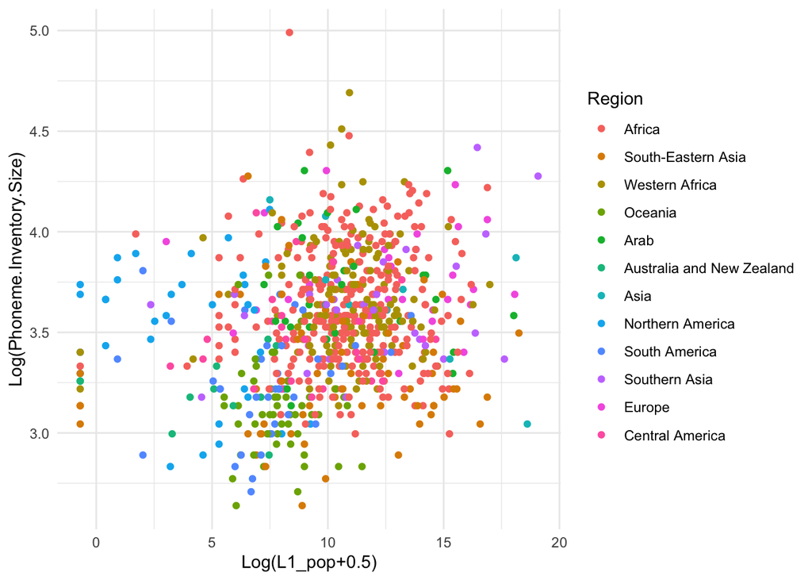

## Testing for region sampling bias

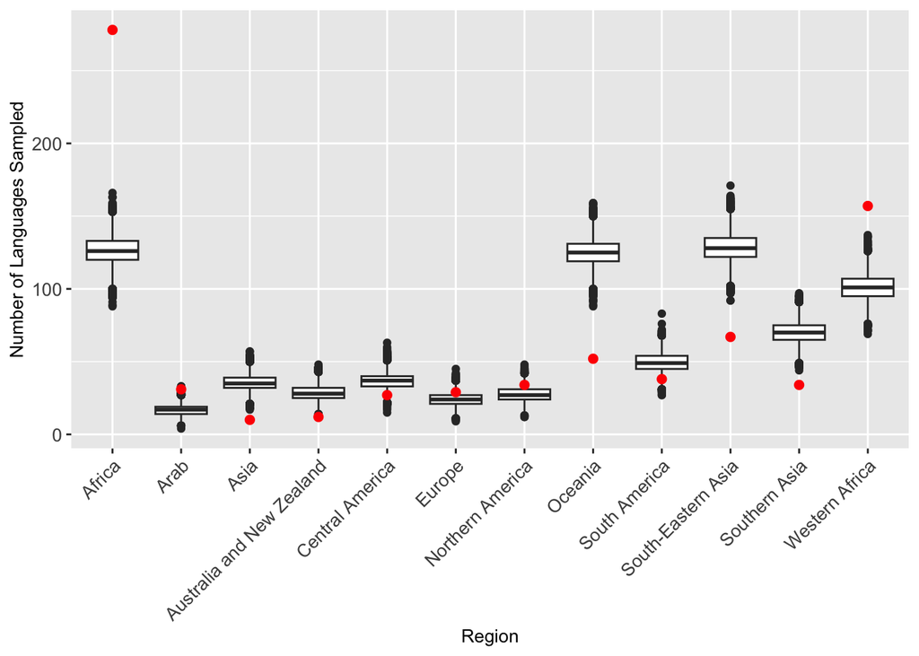

*Randomly sampled languages from (3) data for their region values, and compared sampling distribution with observed region values in A1 data.*

# Phoneme.Inventory.Size across regions

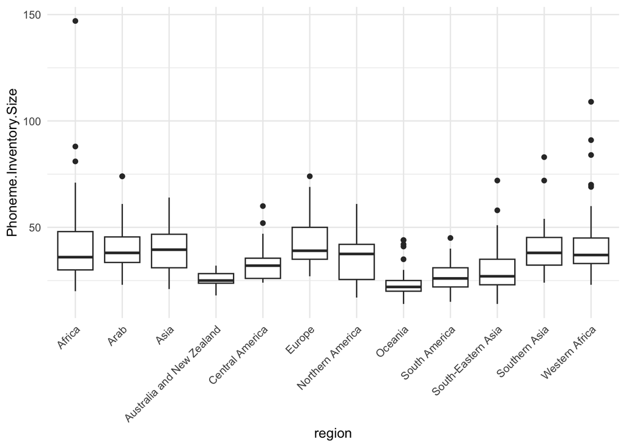

## Results using 2019 (2) method

```
## [1] "Coefficients and p-values"
```

```
##                   Value   Std.Error   t-value    p-value
## (Intercept) 3.444216584 0.049573328 69.477211 0.00000000
## L1_pop      0.006668259 0.003701715  1.801397 0.07203289
```

```
## [1] "Log likelihood:  -105.472779984086"
```

```
## [1] "BIC:  230.880832876689"
```

# References

1. Bromham, L., Yaxley, K.J. & Cardillo, M. Islands are engines of language diversity. *Nat Ecol Evol* **8**, 1991–2002 (2024). https://doi.org/10.1038/s41559-024-02488-4
2. Hua, X., Greenhill, S.J., Cardillo, M. *et al.* The ecological drivers of variation in global language diversity. *Nat Commun* **10**, 2047 (2019). https://doi.org/10.1038/s41467-019-09842-2
3. Bromham, L., Dinnage, R., Skirgård, H. *et al.* Global predictors of language endangerment and the future of linguistic diversity. *Nat Ecol Evol* **6**, 163–173 (2022). https://doi.org/10.1038/s41559-021-01604-y
4. Cormac Anderson, Tiago Tresoldi, Simon J Greenhill, Robert Forkel, Russell Gray, Johann-Mattis List, Variation in phoneme inventories: quantifying the problem and improving comparability, *Journal of Language Evolution*, Volume 8, Issue 2, July 2023, Pages 149–168, https://doi.org/10.1093/jole/lzad011